# Predator, prey and strandings: An IBM approach to modelling the ‘Blue Fleet’

J.M. Sassen

2023-05-22

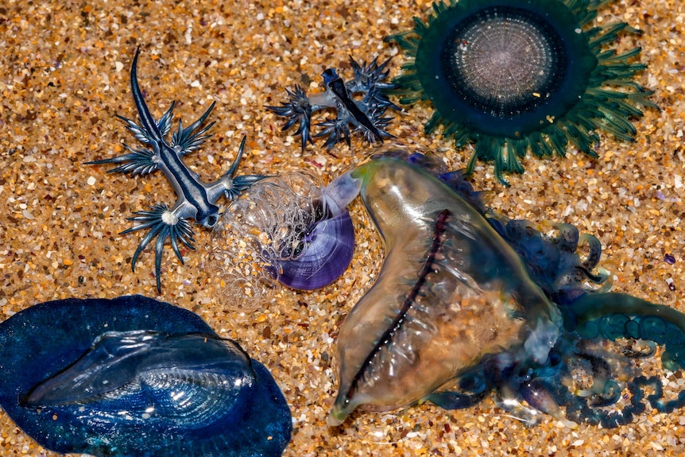

# 1. Introduction

The blue fleet refers to a community of neustonic (i.e. drifting or floating with winds and currents) marine organisms, with a cosmopolitan distribution (Bourg *et al*., 2022). The community consists of several species of Cnidarians as well as a variety of Molluscs (Helm, 2021). Aggregations of these organisms may cover extremely large areas, sometimes spanning several kilometers. Whilst large fleets are generally confined to offshore areas, such as oceanic gyres, strong onshore winds and currents can cause mass strandings of these creatures (Bourg *et al*., 2022). This poses a risk to swimmers and beachgoers, as several constituent species possess the ability to envenomate people or animals upon touch (e.g. the Bluebottle). The exact dynamics driving stranding of harmful species are not completely understood, however this is an area of active research (e.g. Bourg *et al*., 2022; Lee *et al*., 2021). Interestingly, there is some variability in the number of species that one might find during a mass stranding event: sometimes we see all species strand, whilst at other times only one species may be recorded (Grove, 2010). This could be explained by the inherent morphological differences between the species that make up the blue fleet. For example, several cnidarians, including the bluebottle (*Physalia physalis*) and the by-the-wind sailor (*Vellela vellela*), have evolved an enlarged membrane filled with gas that serves as a rudimentary sail (Lee *et al*., 2021). Individual bluebottles come in a right or left-sailed orientation: these two morphotypes will drift in opposite directions from each other (Bourg *et al*., 2022; Lee *et al*., 2021). Other functional groups, such as the pelagic slugs that prey on the floating cnidarians, lack such structures. Thus, whilst all these species are considered part of the blue fleet, physical forces might affect them in different ways.

Here, we simulate the drifting dynamics of two species that are part of the blue fleet: The bluebottle *Physalia physalis* (Cnidaria: Siphonophora) and The ‘Blue Dragon’ *Glaucus atlanticus* (Gastropoda: Nudibranchia), a pelagic sea slug and a predator of *P. physalis*. Drifting behaviour, and associated beaching probabilities for each species were investigated through the use of an Individual Based Model (IBM). We incorporate meaningful ecological interactions between the two species, such as predation, to promote realism of the drifting dynamics. Not much is known about how Blue Dragons find their prey. However, it is possible that they are capable of very limited directed movement, as well as chemodetection of nearby prey using specialised structures known as rhinophores (Valdes & Compillo, 2004). Helm (2021) found that different species of pelagic slugs displayed distinct predatory preferences and behaviour when exposed to prey in a laboratory environment. Alternatively, prey density might be so high that Blue Dragons simply rely on chance encounters with prey. By simulating this system with different combinations of prey densities and biological parameters, we aim to generate insights into how a small neustonic predator finds prey.

We thus strive to answer the following questions:

1. *How do beaching probabilities differ between Glaucus atlanticus and Physalia physalis?*
2. *How do prey density, swimming speed and chemodetection affect the number of predator-prey interactions?*

# 2. Model Elaboration

## 2.1 Conceptual Overview

Whilst the grid resolution was 1km, our model allows individuals to move through continuous space. The movement of an individual depends on the winds and current within the current cell. However the effect of these drivers might only amount to a movement of, for example, 20 cm within a timestep. This value is used to update the position of the individual. On the next iteration, the individual will simply ‘feel’ the same physical drivers, as it still finds itself in the same cell. Thus, movement is decoupled from grid cells, but the effect of wind and currents on the position of an individual does depend on the grid cell they are in. This enables us to include the biological interactions that occur on the scale of centimeters.

- *Note: I initially opted for a grid approach as I was thinking about assigning distinct directions and speeds to different parts of the simulated environment. I did not end up doing this, so the grid structure is not really necessary, however I left it in as it makes no difference and allows me to maybe make those changes in a future version.*

## 2.2 Movement Equations

### 2.2.1 Glaucus atlanticus

$$X_{j,i+1} =
\text{Position}\,\text{along}\,\text{the}\,\text{East-West}\,\text{Axis
for}\,Individual_{j }\text{ at}\,\text{Time = }\,i+1 \\
X_{ij} =
\text{Position}\,\text{along}\,\text{the}\,\text{East-West}\,\text{Axis
for}\,Individual_{j }\text{ at}\,\text{Time = }\,i \\
Y_{j,i+1} =
\text{Position}\,\text{along}\,\text{the}\,\text{North-South}\,\text{Axis
for}\,Individual_{j }\text{ at}\,\text{Time = }\,i+1 \\
Y_{ij} =
\text{Position}\,\text{along}\,\text{the}\,\text{North-South}\,\text{Axis
for}\,Individual_{j }\text{ at}\,\text{Time = }\,i \\
WindSpeed_{xy,i} = \text{Wind Speed}\,\text{in}\,
cell_{X,Y},\text{at}\,\text{Time = }\,i \\
WindDirection_{xy,i} = \text{Wind Direction}\,\text{in}\,
cell_{X,Y},\text{at}\,\text{Time = }\,i \\
CurrentSpeed_{xy,i} = \text{Current Speed}\,\text{in}\,
cell_{X,Y},\text{at}\,\text{Time = }\,i \\
CurrentDirection_{xy,i} = \text{Current Direction}\,\text{in}\,
cell_{X,Y},\text{at}\,\text{Time = }\,i \\
GlaucusSpeed_{j} = \text{Swimming Speed}\,\text{for}\, Individual_{j }
\\
Y_{prey} = \text{Y coordinate of closest prey for}\, Individual_{j }
\text{ at Time = } i \\
X_{prey} = \text{X coordinate of closest prey for}\, Individual_{j }
\text{ at Time = } i \\
Prey = ∀Physalia \\
C = \begin{cases}
1, & \text{if Prey within } Detection Range_j \\
0, & \text{if Prey beyond } Detection Range_j
\end{cases} \\
DetectionRange_{j} = \text{Detection range}\,\text{for}\, Individual_{j
} \\$$

$$\Delta_{x} = sin(1.5 * pi) * speed = -1*speed \\
\Delta_{y} = cos(1.5*pi) * speed = 0*speed = 0 \\
\text{Thus, wind from the east will move an individual to the west at a
non-zero speed}$$

In addition, we allow *G. atlanticus* to make small directed movements towards prey, if their prey is within a certain ‘detection zone’. The size of this detection zone depends on the chemodetection abilities of an individual *G. atlanticus*. If a prey item is within the zone, we calculate the angle in radians between the predator and the prey, and multiply this new direction by the speed of that particular *G. atlanticus*. The *G. atlanticus* will always move to the closest prey item it detects.

```r
# Movement of Glaucus: depends on an individual glaucus and the physalia fleet
glaucusMovement <- function(glaucus, physalia){

  # Boundary conditions for movement, i.e. out of frame.
  # stop updating if this is the case
  if(glaucus$y >= 100 | glaucus$y <= 1 | glaucus$x >= 10){
    return(glaucus)}

  # First check if glaucus are 'latched on' to physalia which will
  # affect their movement. The physalia has to be alive.
  if(!is.na(glaucus$target_ID) & physalia[glaucus$target_ID,'status'][1] != 'EATEN'){
    glaucus$x <- physalia[glaucus$target_ID,'x']
    glaucus$y <- physalia[glaucus$target_ID,'y']
    glaucus$latch_time <- glaucus$latch_time + 1
    glaucus$total_latch_time <- glaucus$total_latch_time + 1

    # Probability of glaucus detaching follows a beta prime distribution.
    # Shape of distribtution set to match expected behaviour - though arbitrary.

    probs <- c(1-pbetapr(glaucus$latch_time, 24, 5), pbetapr(glaucus$latch_time, 24, 5))
    glaucus$target_ID <- sample(size=1, x = c(glaucus$target_ID, NA), prob = probs) # NA corresponds to letting go of prey.

  }else{


    # Check the Glaucus is not beached, if OK, proceed with movement update
    # as effect of physical forces
    if(glaucus$x > 1){

      # Positional update rules: movement of a Glaucus
      # We use ceiling() to round up and extract force values from the grids.
      # The grids are set globally prior to function call.
      glaucus$x <- glaucus$x + 0.01*wind_strength[ceiling(glaucus$y),
                                                   ceiling(glaucus$x)] * sin(wind_direction[ceiling(glaucus$y),
                                                                                            ceiling(glaucus$x)])+
        0.005 * current_strength[ceiling(glaucus$y),
                                 ceiling(glaucus$x)] * sin(current_direction[ceiling(glaucus$y),
                                                                             ceiling(glaucus$x)])

      # Y movement (north - south) uses cosine function
      glaucus$y <- glaucus$y + 0.01*wind_strength[ceiling(glaucus$y),
                                                   ceiling(glaucus$x)] * cos(wind_direction[ceiling(glaucus$y),
                                                                                            ceiling(glaucus$x)]) +
        0.005 * current_strength[ceiling(glaucus$y),
                                 ceiling(glaucus$x)] * cos(current_direction[ceiling(glaucus$y),
                                                                             ceiling(glaucus$x)])

      ### Predator module - handles the predator behaviour

      # Glaucus are predators. They can detect prey from distance using chemical cues. We want to simulate these capabilities
      # by allowing glaucus limited movement to a target, if the target is within reasonable range.

      # scan area for each glaucus
      # Convert to spatial geometries to allow geometric operations.
      spat.point <- st_point(c(glaucus$x, glaucus$y))

      # Chemodetection range calculated as circle with radius equal to
      # the predetermined parameter.
      detection.zone <- st_buffer(spat.point, glaucus$chemodetection)

      # Find the Physalia that are within the detection zone.
      physalia.df.spat <- st_as_sf(physalia , coords = c('x', 'y'))

      # Any prey in the detection zone?
      if(any(st_intersects(physalia.df.spat, detection.zone, sparse = F))){
        # Find the nearest Physalia
        print('Attack!') # to check if all is ok

        # extract some info on the prey
        glaucus.target <- physalia.df.spat[[which.min(st_distance(spat.point, physalia.df.spat)),'geometry']]
        glaucus.target.id <- physalia.df.spat[[which.min(st_distance(spat.point, physalia.df.spat)),'ID']]

        # Now make it move towards the target. We just assume it
        # is quite good at sensing prey so its movement is
        # directed.

        target_angle <- atan2(glaucus.target[2] - glaucus$y, glaucus.target[1] - glaucus$x) # atan2 calculates the angle to get from y to x
        glaucus$x <- glaucus$x + glaucus$speed * cos(target_angle)
        glaucus$y <- glaucus$y +  glaucus$speed * sin(target_angle)

        # track interaction - defined as entities being close enough to change behaviour
        # i.e. sensing, eating, latching
        glaucus$interaction <- as.numeric(glaucus$interaction) + 1

        # Latch-on module
        eating.zone <- st_buffer(spat.point, 0.0005)
        if(st_intersects(physalia.df.spat[glaucus.target.id,], eating.zone, sparse = F)){
          print('LATCHED')

          # Identify the prey to latch on and store as glaucus attribute
          glaucus$target_ID <- glaucus.target.id

        }
      }


    } else{
      glaucus$status <- 'BEACHED' # glaucus is beached
    }
  }
  return(glaucus)
}
```

### 2.2.2 Physalia physalis

$$X_{j,i+1} = X_{ij} + 0.0266*(WindSpeed_{{xy,i}} *
sin(WindDirection_{xy,i}+ D_{ij})) + 0.001 *CurrentSpeed_{xy,i} *
sin(CurrentDirection_{xy,i}) \\
Y_{j,i+1} = Y_{ij} + 0.0266*(WindSpeed_{{xy,i}} *
cos(WindDirection_{xy,i}+ D_{ij})) + 0.001 * CurrentSpeed_{xy,i} *
cos(CurrentDirection_{xy,i})$$

*Where:*

$$X_{j,i+1} =
\text{Position}\,\text{along}\,\text{the}\,\text{East-West}\,\text{Axis
for}\,Individual_{j }\text{ at}\,\text{Time = }\,i+1 \\
X_{ij} =
\text{Position}\,\text{along}\,\text{the}\,\text{East-West}\,\text{Axis
for}\,Individual_{j }\text{ at}\,\text{Time = }\,i \\
Y_{j,i+1} =
\text{Position}\,\text{along}\,\text{the}\,\text{North-South}\,\text{Axis
for}\,Individual_{j }\text{ at}\,\text{Time = }\,i+1 \\
Y_{ij} =
\text{Position}\,\text{along}\,\text{the}\,\text{North-South}\,\text{Axis
for}\,Individual_{j }\text{ at}\,\text{Time = }\,i \\
WindSpeed_{xy,i} = \text{Wind Speed}\,\text{in}\,
cell_{X,Y},\text{at}\,\text{Time = }\,i \\
WindDirection_{xy,i} = \text{Wind Direction}\,\text{in}\,
cell_{X,Y},\text{at}\,\text{Time = }\,i \\
CurrentSpeed_{xy,i} = \text{Current Speed}\,\text{in}\,
cell_{X,Y},\text{at}\,\text{Time = }\,i \\
CurrentDirection_{xy,i} = \text{Current Direction}\,\text{in}\,
cell_{X,Y},\text{at}\,\text{Time = }\,i \\
D_{ij} = \begin{cases}
normal(pi/3, 0.25) & \text{if Orientation}_j = Right \\
normal(-pi/3,0.25) & \text{if Orientation}_j = Left
\end{cases} \text{at Time = } i \\
Orientation_j = \text{Sail Orientation of Individual}_j$$

```r
# Movement of Physalia
physaliaMovement <- function(physalia, glaucus){

  # Boundary conditions for movement, i.e. out of frame
  # stop updating if this happens
  if(physalia$y >= 100 | physalia$y <= 1 |physalia$x >= 100){

    return(physalia)}

  # Check Physalia is alive and not beached
  if(physalia$x > 1 & physalia$status != 'EATEN'){

    ### Predator-prey module

    # We want to simulate damage to the physalia, i.e. being killed by a predator.
    # We use a simple rule: if the glaucus is within feeding range of the physalia
    # for 24 hours, the physalia has been eaten completely. The glaucus will then also
    # move on as we assign status 'eaten' to the physalia.

    # Convert to spatial geometries to allow geometric operations.
    spat.point <- st_point(c(physalia$x, physalia$y))

    # We can decide what a reasonable buffer is. This is the same for
    # all physalia.
    under.attack.zone <- st_buffer(spat.point, 0.0005)

    # Check if there is a predator nearby
    glaucus.df.spat <- st_as_sf(glaucus , coords = c('x', 'y'))

    # Any predators in the detection/eating zone?
    if(any(st_intersects(glaucus.df.spat, under.attack.zone, sparse = F))){

      # If yes, the physalia is 'under attack'
      physalia$underattack <- physalia$underattack + 1
    }
    # Check if physalia is eaten
    if(physalia$underattack >= 24){
      physalia$status <- 'EATEN'
    }

    # We have right and left=handed bluebottles
    # They drift in opposite directions - presumably to sustain populations.
    # We need to account for this properly. In addition, we want to add some
    # stochasticity to the movement. This is due to inherent variability
    # in the shape and size of bluebottles, but also due to waves etc.

    if(physalia$orientation == 'right') {direction_offset <- rnorm(1,1,0.25)*pi/3} # right-handed drift at 50 degrees from wind direction.
    if(physalia$orientation == 'left') {direction_offset <- rnorm(1,-1,0.25)*pi/3} # left handed drift at ``

    # Positional update rules:
    # Wind has a larger impact on physalia due to the sail
    # physalia also have an offset - their sails change the way they interact with wind.
    # We also assume current has a slightly smaller effect on them than on glaucus

    # 0.0266 - see Lee, Schaeffer, Groeskamp (2021) for justification.
    physalia$x <- physalia$x + 0.0266*(wind_strength[ceiling(physalia$y),
                                                     ceiling(physalia$x)]) * sin(wind_direction[ceiling(physalia$y),
                                                                                                          ceiling(physalia$x)]+ direction_offset) +
      0.001* current_strength[ceiling(physalia$y),
                              ceiling(physalia$x)] * sin(current_direction[ceiling(physalia$y),
                                                                                     ceiling(physalia$x)])

    # Y movement (north - south) uses cosine function
    physalia$y <- physalia$y + 0.0266*(wind_strength[ceiling(physalia$y),
                                                     ceiling(physalia$x)]) * cos(wind_direction[ceiling(physalia$y),
                                                                                                          ceiling(physalia$x)] + direction_offset) +
      0.001* current_strength[ceiling(physalia$y),
                              ceiling(physalia$x)] * cos(current_direction[ceiling(physalia$y),
                                                                                     ceiling(physalia$x)])

  } else{

    # Check if individual is beached
    if(physalia$x <= 1){
      physalia$status <- 'BEACHED'
    }
  }
  return(physalia)
}
```

### 2.3 Biological Interactions

Both species are able to interact with each other in the model, and this potentially affects their movements. *G. atlanticus* will seek out nearby *P. physalis* as described in section 2.2.1. However, they may also ‘latch’ on to a *P. physalis*. This emulates feeding behaviour in which *G. atlanticus* move within the tentacles of a *P. physalis*: *G. atlanticus* may then move with the *P. physalis*, until it stops feeding or completely depletes the resource. Consequently, the time it takes to deplete the resource equals the time it takes for a *P. physalis* to be killed. We assume that an individual *P. physalis* cannot survive unlimited attacks by *G. atlanticus*, and thus an individual that spends more than 24 hours ‘under attack’ will be assigned the status ‘EATEN’ and no further movements are simulated. Any *G. atlanticus* that was ‘latched on’ to the deceased prey, then reverts to their regular movement equations. Individual *G. atlanticus* may also detach from prey before consuming it. We model detachment using a beta prime distribution (α = 24, β = 5), by letting the probability of detaching equal the probability of observing a given latch time from the specified beta prime distribution.

### 2.4 Stochasticity of Winds and Currents

We strived to emulate the wind and current regime of the East Australian coastline. The primary current is the EAC, which flows in a southward direction. The current speed was initialized at a 5 km/H; this was deemed reasonable as the top speed of the EAC is around 7 km/H (Middleton *et al*., 1996). We then allowed speeds to increase or decrease stochastically, within a range of 2 km/H - 7 km/H. Wind and current direction were initialized at 315° and 180° and allowed to vary: wind direction varies between 225° and 315°, whilst current direction varies between 160° and 200°. This approach directions did not ‘jump’ randomly, but instead changed due to small stochastic increases or decreases. These ranges were based on available data (WillyWeather, 2023; Middleton *et al*., 1996).

Wind speed was modeled following a slightly different approach. Wind speed generally follows a daily cycle, in which wind builds up throughout the day. We simulated this using a sine function with added gaussian noise - this function is featured in the following code chunk.

```r
# Stochastic parameter wind strength
wind_strength_calc <-function(hour) {
  # Parameters for the sinusoidal function
  peak_hour <- 20        # Hour of the day with maximum wind
  amplitude <- 5       # Amplitude of the sinusoidal function (half of the variation)


  # Calculate speed using a sine
  strength = amplitude * sin((hour - peak_hour) * 2 * pi / 24) + 10
  strength = (strength + rnorm(length(hour), 0, sd = 3))
  strength[which(strength<0)] <- 0
  return(strength)
}
```

# 3. Model Simulations

In order to effectively answer our research questions, we designed a simulation strategy consisting of two distinct parts: i) running 32 replicates of the simulation using fixed behavioral parameters and assessing beaching proportions of each species and ii) running 50 simulations, each with a different combination of chemodetection range and swimming speed between 0 and 20 meters, obtained from a Latin Square Sampling design, at three different densities of *P. physalis* (a total of 150 unique simulations). All simulations were run on a HPC cluster - bash scripts used are included in the appendix.

## 3.1 Simulation Function

We created a main simulation function that handles creation of the environment, instantiation of agents, and movement updates based on a fixed number of hours or iterations. The function takes 11 parameters to achieve this.

- **iniSpace**: A vector of 4 coordinates denoting a bounding box of where on the gridyou wish to initialise agents.
- **nTimes**: Number of simulation iterations.
- **n_rows**: Height of grid (km)
- **n_cols**: Width of grid (km)
- **nPhysalia**: Number of *P. physalis*
- **nGlaucus**: Number of *G. atlanticus*
- **strength_current**: Inital current speed (km/h)
- **dir_current**: Initial current direction
- **dir_wind**: Initial wind direction
- **Glaucus_chemodetection**: mean chemodetection range for *G. atlanticus* population.
- **Glaucus_speed**: mean swimming speed for *G. atlanticus* population.

```r
# Function for running simulation
simBlueFleet.stochPhys <- function(nTimes,n_rows, n_cols, nPhysalia, nGlaucus,
                                   strength_current,
                                   dir_wind, dir_current,
                                   glaucus_Chemodetection, glaucus_Speed, iniSpace){

  # Assign wind and current speed and direction to each grid cell.
  # Based on param input
  current_strength <<- matrix(rep(strength_current,n_rows*n_cols),
                              nrow=n_rows)

  # Wind and current directions

  wind_direction <<- matrix(rep(dir_wind, n_rows*n_cols),
                            nrow=n_rows, ncol=n_cols)
  current_direction <<- matrix(rep(dir_current, n_rows*n_cols),
                               nrow=n_rows, ncol=n_cols)


  ### Instantiate model agents

  # Glaucus atlanticus individuals
  print('Generating animals')
  # Our individuals also have attributes. Glaucus are our predators.
  # They will seek out Physalia, and are capable of (very limited)
  # powered movement.

  glaucus <- data.frame(matrix(nrow=nGlaucus, ncol=10))
  colnames(glaucus) <- c("ID", "x", "y", "chemodetection", "speed", "latch_time","total_latch_time", "target_ID", "interaction", "status")
  for (i in 1:nGlaucus) {
    glaucus[i,] <- list(
      ID = i,
      x = round(runif(1, iniSpace$xmin, iniSpace$xmax),3),
      y = round(runif(1, iniSpace$ymin, iniSpace$ymax),3),
      chemodetection = rnorm(1, glaucus_Chemodetection, glaucus_Chemodetection/4),
      speed = rnorm(1,glaucus_Speed, sd = glaucus_Speed/4),
      latch_time = 0,
      total_latch_time = 0,
      target_ID = NA,
      interaction = 0,
      status = 'ALIVE'
    )
  }

  # Set up bluebottle movement and functions. Bluebottles can be right
  # or left handed.
  physalia <- data.frame(matrix(nrow=nPhysalia, ncol=6))
  colnames(physalia) <- c("ID", "x", "y", "underattack", "status", "orientation")

  for (i in 1:nPhysalia) {
    physalia[i,] <- list(
      ID = i,
      x = round(runif(1, iniSpace$xmin, iniSpace$xmax),3),
      y = round(runif(1, iniSpace$ymin, iniSpace$ymax),3),
      underattack = 0,
      status = 'ALIVE',
      orientation = sample(c('left', 'right'),1)
    )
  }

  print('Simulating Dynamics')
  GlaucusSim <- list()
  PhysaliaSim <- list()

  # Run model over nTimes steps.
  for (i in 1:nTimes){
    print(i)
    wind_strength <<- matrix(rep(wind_strength_calc(i),n_rows*n_cols),
                             nrow=n_rows)
    # Wind and current directions vary each hour, but within boundaries
    dir_wind = ifelse(rnorm(1, dir_wind, 0.1) > 1.75*pi, 1.75*pi,
                      ifelse(rnorm(1, dir_wind, 0.1) < 1.25*pi, 1.25*pi,
                             rnorm(1, dir_wind, 0.1))) |> sin()


    dir_current = ifelse(rnorm(1, dir_current, 0.1) > 3.5, 3.5,
                         ifelse(rnorm(1, dir_current, 0.1) < 2.9, 2.9,
                                rnorm(1, dir_current, 0.1)))

    strength_current = ifelse(rnorm(1, strength_current, 0.1) > 7, 7,
                         ifelse(rnorm(1, strength_current, 0.1) < 2, 2,
                                rnorm(1, strength_current, 0.1)))

    wind_direction <<- matrix(rep(dir_wind, n_rows*n_cols),
                              nrow=n_rows, ncol=n_cols)
    current_direction <<- matrix(rep(dir_current, n_rows*n_cols),
                                 nrow=n_rows, ncol=n_cols)
    current_strength <<- matrix(rep(strength_current,n_rows*n_cols),
                                nrow=n_rows)

    # Update Physalia movement
    for(k in 1:nPhysalia){

      # This function updates the position of all simulated
      # Physalia. Also tracks their 'status', which may be one
      # of 'ALIVE', 'BEACHED', or 'EATEN'.
      physalia[k, ] <- physaliaMovement(physalia[k,], glaucus)
    }

    PhysaliaSim[[i]] <- physalia


    # Update Glaucus movement. Status includes 'BEACHED' or 'ALIVE'.
    for(j in 1:nGlaucus){
      glaucus[j,] <- glaucusMovement(glaucus[j,], physalia)

    }
    GlaucusSim[[i]] <- glaucus
  }
  simResults <- list('GlaucusSim' = GlaucusSim,
                     'PhysaliaSim' = PhysaliaSim)

  return(simResults)
}
```